# Regresi Linear Sederhana

Sahda Huwaidah Estiningtyas

2024-04-18

# Membaca Data

```r
# Membaca data
education <- read.table("C:/Users/LENOVO/OneDrive/Documents/UNY/Semester 2/edu.txt", header = TRUE)

# Menampilkan struktur data
str(education)
```

```
## 'data.frame':    12 obs. of  2 variables:
##  $ YearsOfExperience: int  5 10 15 3 8 12 4 9 14 6 ...
##  $ Salary           : int  40000 50000 60000 35000 48000 55000 38000 52000 58000 42000 ...
```

```r
# Memeriksa data
head(education)
```

```
##   YearsOfExperience Salary
## 1                 5  40000
## 2                10  50000
## 3                15  60000
## 4                 3  35000
## 5                 8  48000
## 6                12  55000
```

```r
# Memeriksa panjang data
x <- c(5,10,15,3,8,12,4,9,14,6,11,16)
y <- c(40000,50000,60000,35000,48000,55000,38000,52000,58000,42000,53000,62000)
panjang_x <- length(x)
panjang_y <- length(y)
print(panjang_x)
```

```
## [1] 12
```

```r
print(panjang_y)
```

```
## [1] 12
```

# Eksplorasi Data

```r
summary(education)
```

```
##  YearsOfExperience     Salary
##  Min.   : 3.000    Min.   :35000
##  1st Qu.: 5.750    1st Qu.:41500
##  Median : 9.500    Median :51000
##  Mean   : 9.417    Mean   :49417
##  3rd Qu.:12.500    3rd Qu.:55750
##  Max.   :16.000    Max.   :62000
```

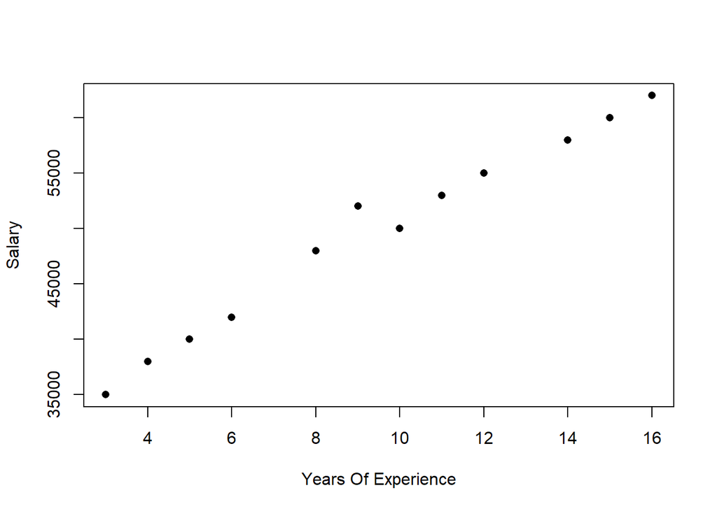

```r
plot(education$YearsOfExperience, education$Salary, xlab="Years Of Experience", ylab="Salary",pch=16)
```

# Persamaan Regresi

```r
modela<-lm(Salary~YearsOfExperience,data=education)
summary(modela)
```

```
##
## Call:
## lm(formula = Salary ~ YearsOfExperience, data = education)
##
## Residuals:
##     Min      1Q  Median      3Q     Max
## -1396.5  -724.1  -469.3   348.7  3428.8
##
## Coefficients:
##                   Estimate Std. Error t value Pr(>|t|)
## (Intercept)       30309.13     975.48   31.07 2.80e-11 ***
## YearsOfExperience  2029.12      94.71   21.43 1.09e-09 ***
## ---
## Signif. codes:  0 '***' 0.001 '**' 0.01 '*' 0.05 '.' 0.1 ' ' 1
##
## Residual standard error: 1369 on 10 degrees of freedom
## Multiple R-squared:  0.9787, Adjusted R-squared:  0.9765
## F-statistic:   459 on 1 and 10 DF,  p-value: 1.094e-09
```

Persamaan regresi yang diberikan menunjukkan hubungan antara gaji ($\text{Salary}$) dengan pengalaman ($\text{YearsOfExperience}$). Hasil analisis menunjukkan bahwa intercept ($\beta_0$) memiliki nilai sekitar $\$30309.13$, yang mengindikasikan bahwa bagi individu dengan pengalaman nol tahun, gaji yang diharapkan adalah sekitar $\$30309.13$. Sementara itu, nilai slope ($\beta_1$) sebesar $2029.12$ menunjukkan bahwa setiap tambahan satu tahun dalam pengalaman dikaitkan dengan peningkatan rata-rata sebesar $\$2029.12$ dalam gaji. Dengan demikian, model ini menunjukkan bahwa pengalaman memiliki pengaruh signifikan terhadap gaji, dengan peningkatan pengalaman yang berkelanjutan berpotensi meningkatkan gaji secara substansial. Hasil analisis juga menunjukkan bahwa model memiliki nilai $R^2$ sebesar 0.9787, menunjukkan bahwa sekitar 97.87% variabilitas dalam gaji dapat dijelaskan oleh variabel independen (pengalaman). Nilai p-value yang sangat kecil (1.09e-09) menegaskan signifikansi statistik dari hubungan antara pengalaman dan gaji. Oleh karena itu, dapat disimpulkan bahwa pengalaman memiliki pengaruh yang signifikan terhadap gaji, dan model regresi ini dapat digunakan untuk memprediksi gaji berdasarkan pengalaman dengan tingkat kepercayaan yang tinggi.

# Asumsi 1: Rata-rata galat diasumsikan bernilai nol

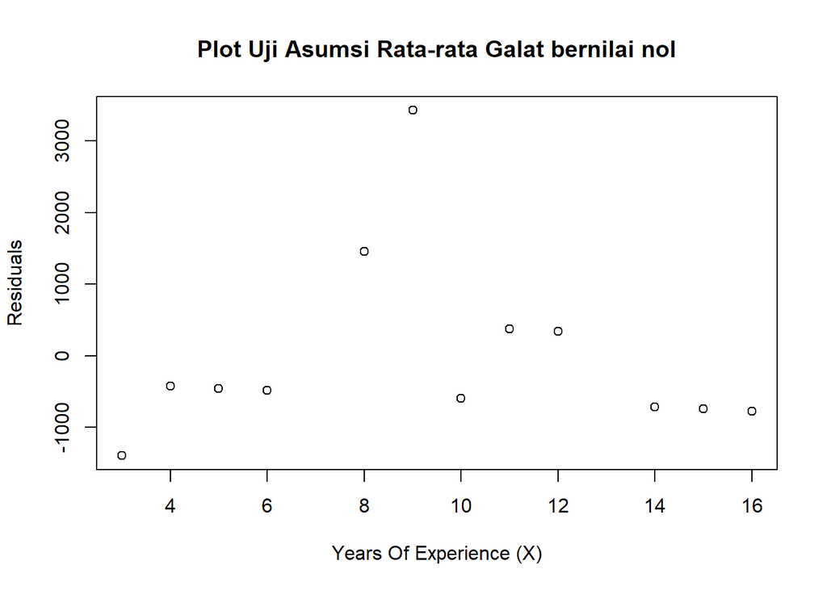

```r
plot(education$YearsOfExperience, modela$residuals,
 xlab="Years Of Experience (X)", ylab="Residuals",
 main="Plot Uji Asumsi Rata-rata Galat bernilai nol")
```

# Asumsi 2: Galat saling bebas

```r
c <- (1:12)
education <- cbind(education, c)
head(education)
```

```
##   YearsOfExperience Salary c
## 1                 5  40000 1
## 2                10  50000 2
## 3                15  60000 3
## 4                 3  35000 4
## 5                 8  48000 5
## 6                12  55000 6
```

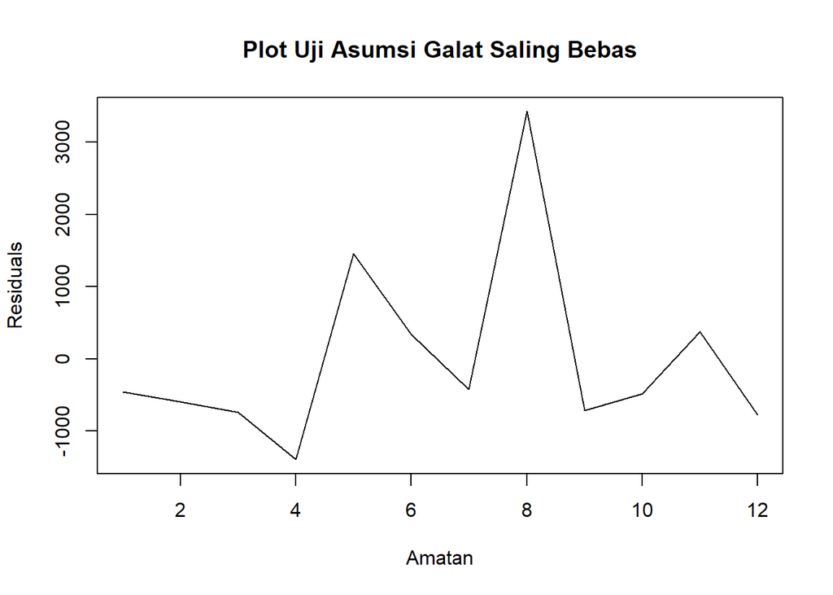

```r
plot(education$c, modela$residuals,
 xlab = "Amatan", ylab = "Residuals", type = "l",
 main = "Plot Uji Asumsi Galat Saling Bebas")
```

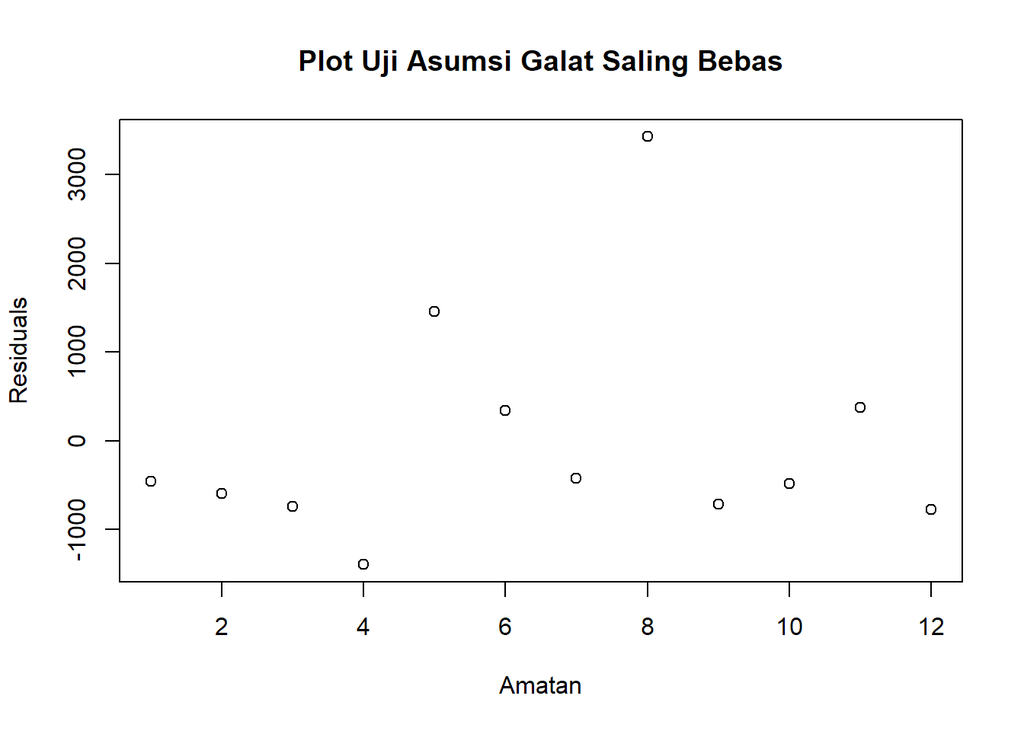

```r
plot(education$c,modela$residuals,
 xlab = "Amatan",ylab="Residuals",
 main = "Plot Uji Asumsi Galat Saling Bebas")
```

# Asumsi 3: Galat berdistribusi normal

```r
c <- (1:12)
# Tabel ANOVA
ytopi <- modela$fitted.values
ei <- modela$residuals
eiterurut <- sort(modela$residuals)
anova(modela)
```

```
## Analysis of Variance Table
##
## Response: Salary
##                   Df    Sum Sq   Mean Sq F value    Pr(>F)
## YearsOfExperience  1 860177137 860177137  459.02 1.094e-09 ***
## Residuals         10  18739529   1873953
## ---
## Signif. codes:  0 '***' 0.001 '**' 0.01 '*' 0.05 '.' 0.1 ' ' 1
```

```r
hi<-sqrt(1873953)*qnorm((c-0.375)/(12+0.25))
Hi<-cbind(education,ytopi,ei,eiterurut,hi)
head(Hi)
```

```
##   YearsOfExperience Salary c    ytopi         ei  eiterurut         hi
## 1                 5  40000 1 40454.73  -454.7268 -1396.4898 -2238.2445
## 2                10  50000 2 50600.32  -600.3191  -775.0299 -1524.8954
## 3                15  60000 3 60745.91  -745.9114  -745.9114 -1083.6931
## 4                 3  35000 4 36396.49 -1396.4898  -716.7930  -733.9846
## 5                 8  48000 5 46542.08  1457.9178  -600.3191  -426.9935
## 6                12  55000 6 54658.56   341.4440  -483.8452  -140.3017
```

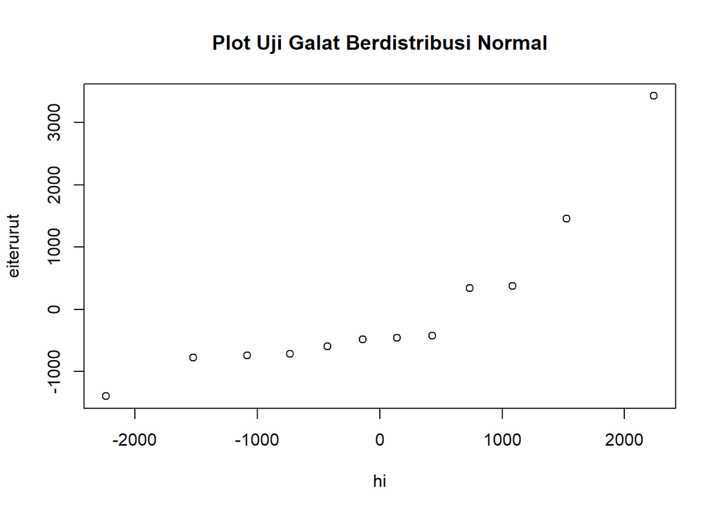

```r
plot(hi,eiterurut,
xlab="hi",ylab="eiterurut",
main="Plot Uji Galat Berdistribusi Normal")
```

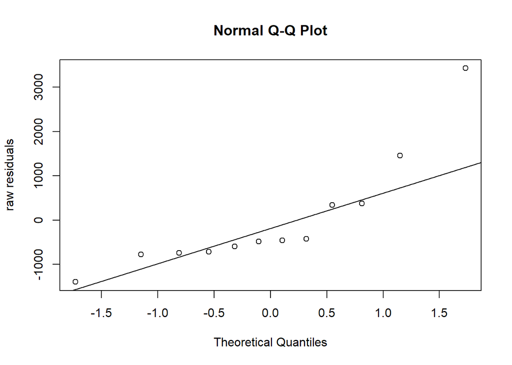

```r
# Fungsi qqnorm dan qqline
qqnorm(modela$residuals, ylab = "raw residuals")
qqline(modela$residuals)
```

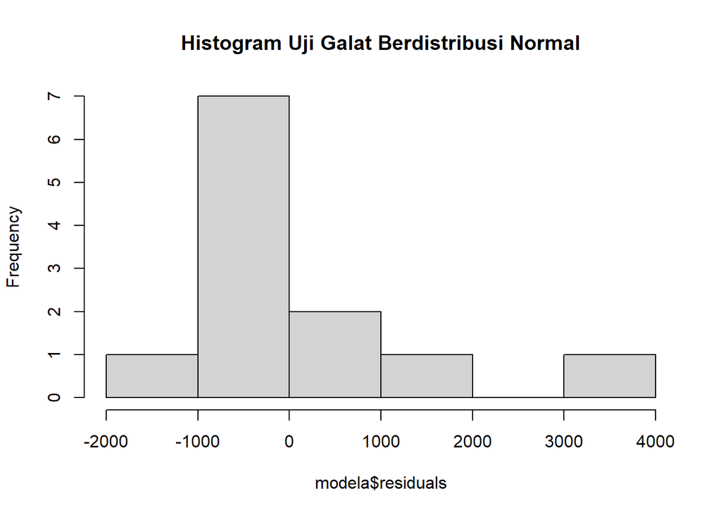

```r
# Histogram Uji Galat Berdistribusi Normal
hist(modela$residuals, main="Histogram Uji Galat Berdistribusi Normal")
```

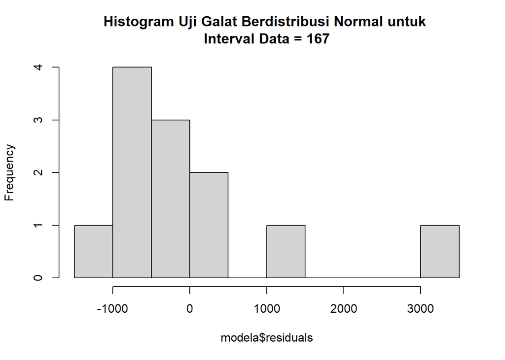

```r
# Histogram untuk interval data = 12
hist(modela$residuals, 12, main="Histogram Uji Galat Berdistribusi Normal untuk
Interval Data = 167")
```

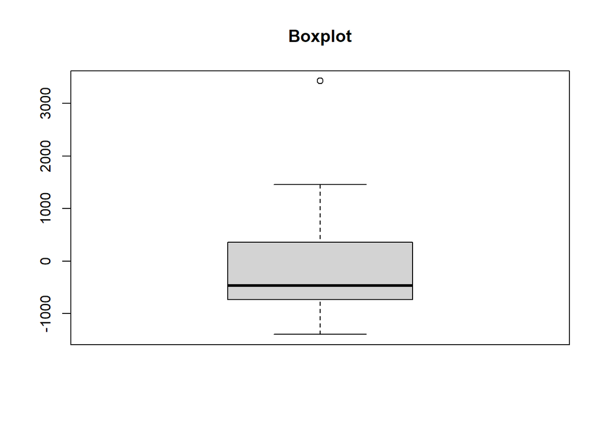

```r
# Boxplot
boxplot(modela$residuals, main="Boxplot")
```

# Asumsi 4: Ragam galat diasumsikan konstan

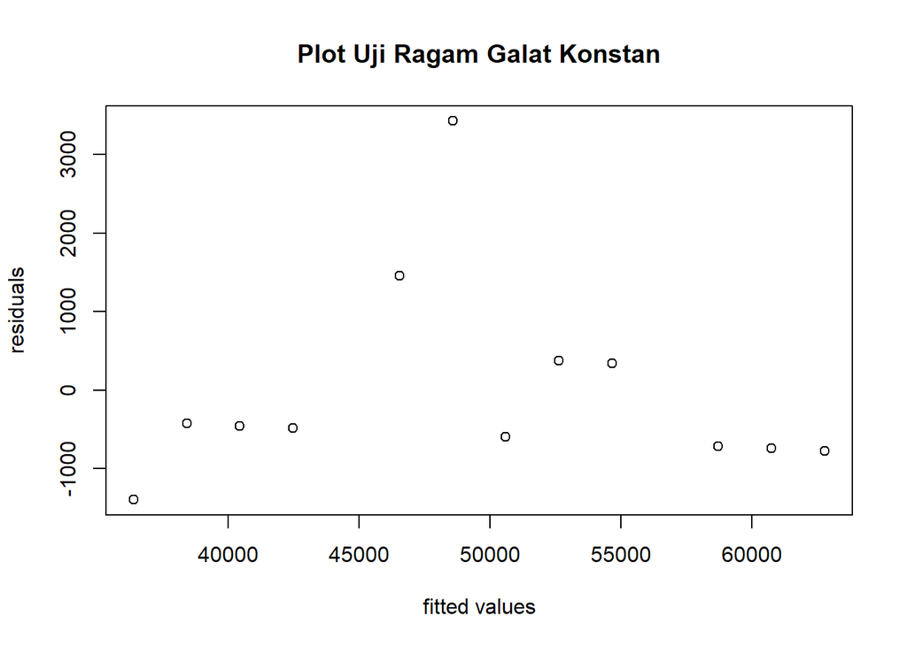

```r
ytopi<-modela$fitted.values
ei<-modela$residuals
plot(ytopi,ei,
 xlab="fitted values", ylab="residuals",
 main="Plot Uji Ragam Galat Konstan")
```

# Asumsi 5: Liearitas antara X dan Y

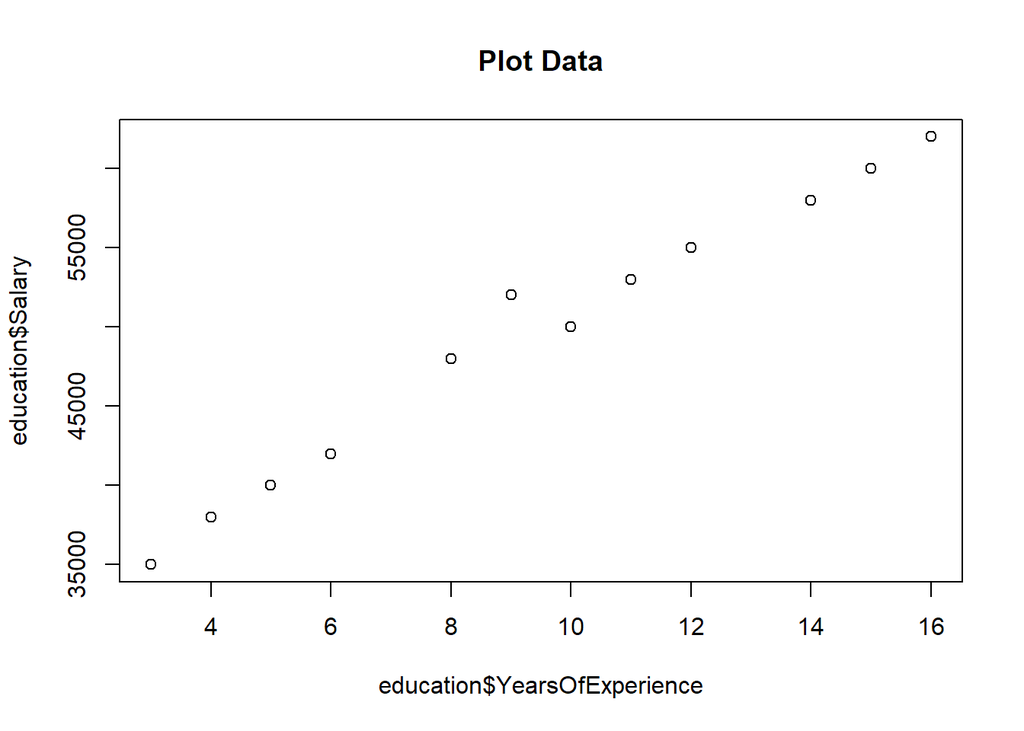

```r
plot(education$YearsOfExperience, education$Salary, main="Plot Data")
```

# Asumsi 6: Tidak ada outlier

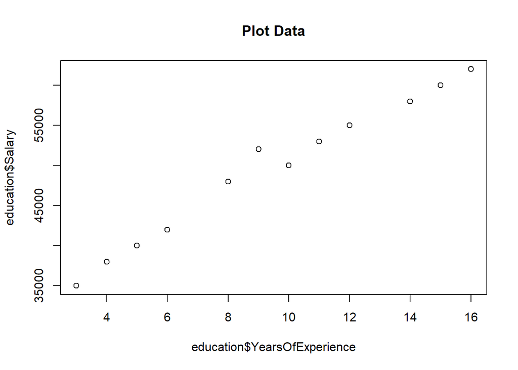

```r
plot(education$YearsOfExperience, education$Salary, main="Plot Data")
```